# LAB 6 WRITE UP

Katherine Bayt

2022-05-11

## The Initial Split

```r
set.seed(3435)
Wage_split <- initial_split(Wage, strata = "wage")

Wage_train <- training(Wage_split)
Wage_test <- testing(Wage_split)
```

## Polynomial Regression and Step Functions

Polynomial Regression - doing poly espansions on a variable and passing that expansion into a linear regression model.

step_poly() - allows us to do polynomial expansion of one or more variables. - will take age and replace it with age, age^2, age^3, and age ^4 (degree=4)

```r
rec_poly <- recipe(wage ~ age, data = Wage_train) %>%
  step_poly(age, degree = 4)
```

Create a linear regreesion specification and combine the recipe with it to create a workflow:

```r
lm_spec <- linear_reg() %>%
  set_mode("regression") %>%
  set_engine("lm")

poly_wf <- workflow() %>%
  add_model(lm_spec) %>%
  add_recipe(rec_poly)
```

Fit the object:

```r
poly_fit <- fit(poly_wf, data = Wage)
poly_fit
```

```
## == Workflow [trained] ==========================================================
## Preprocessor: Recipe
## Model: linear_reg()
##
## -- Preprocessor ----------------------------------------------------------------
## 1 Recipe Step
##
## * step_poly()
##
## -- Model -----------------------------------------------------------------------
##
## Call:
## stats::lm(formula = ..y ~ ., data = data)
##
## Coefficients:
## (Intercept)   age_poly_1   age_poly_2   age_poly_3   age_poly_4
##      111.70       447.07      -478.32       125.52       -77.91
```

Pull the coefficients using tidy()

```r
tidy(poly_fit)
```

| term | estimate | std.error | statistic | p.value |
| --- | --- | --- | --- | --- |
| (Intercept) | 111.70361 | 0.7287409 | 153.283015 | 0.000000e+00 |
| age_poly_1 | 447.06785 | 39.9147851 | 11.200558 | 1.484604e-28 |
| age_poly_2 | -478.31581 | 39.9147851 | -11.983424 | 2.355831e-32 |
| age_poly_3 | 125.52169 | 39.9147851 | 3.144742 | 1.678622e-03 |
| age_poly_4 | -77.91118 | 39.9147851 | -1.951938 | 5.103865e-02 |

step_poly() make a linear combination of the vafiables age, age^2,… We can see this by using poly() with raw = FALSE

```r
poly(1:6, degree = 4, raw = FALSE)
```

```
##               1          2          3          4
## [1,] -0.5976143  0.5455447 -0.3726780  0.1889822
## [2,] -0.3585686 -0.1091089  0.5217492 -0.5669467
## [3,] -0.1195229 -0.4364358  0.2981424  0.3779645
## [4,]  0.1195229 -0.4364358 -0.2981424  0.3779645
## [5,]  0.3585686 -0.1091089 -0.5217492 -0.5669467
## [6,]  0.5976143  0.5455447  0.3726780  0.1889822
## attr(,"coefs")
## attr(,"coefs")$alpha
## [1] 3.5 3.5 3.5 3.5
##
## attr(,"coefs")$norm2
## [1]  1.00000  6.00000 17.50000 37.33333 64.80000 82.28571
##
## attr(,"degree")
## [1] 1 2 3 4
## attr(,"class")
## [1] "poly"   "matrix"
```

Can get the raw transformation by setting raw = TRUE

```r
poly(1:6, degree = 4, raw = TRUE)
```

```
##      1  2   3    4
## [1,] 1  1   1    1
## [2,] 2  4   8   16
## [3,] 3  9  27   81
## [4,] 4 16  64  256
## [5,] 5 25 125  625
## [6,] 6 36 216 1296
## attr(,"degree")
## [1] 1 2 3 4
## attr(,"class")
## [1] "poly"   "matrix"
```

Raw = FALSE vs TRUE: - recommended o use FALSE because it makes the resulting variables uncorrelated, something we want in a linear regression model

Get the raw polynomials by setting options = list(raw = TRUE)

```r
rec_raw_poly <- recipe(wage ~ age, data = Wage) %>%
  step_poly(age, degree = 4, options = list(raw = TRUE))

raw_poly_wf <- workflow() %>%
  add_model(lm_spec) %>%
  add_recipe(rec_raw_poly)

raw_poly_fit <- fit(raw_poly_wf, data = Wage)

tidy(raw_poly_fit)
```

| term | estimate | std.error | statistic | p.value |
| --- | --- | --- | --- | --- |
| (Intercept) | -1.841542e+02 | 6.004038e+01 | -3.067172 | 0.0021802539 |
| age_poly_1 | 2.124552e+01 | 5.886748e+00 | 3.609042 | 0.0003123618 |
| age_poly_2 | -5.638593e-01 | 2.061083e-01 | -2.735743 | 0.0062606446 |
| age_poly_3 | 6.810688e-03 | 3.065931e-03 | 2.221409 | 0.0263977518 |
| age_poly_4 | -3.203830e-05 | 1.641359e-05 | -1.951938 | 0.0510386498 |

# VISUALIZE THE POLYNOMIAL FIT ON OUR DATA

1. create a tibble with different ranges of age
2. take this tibble and predict with it to get the regression curve
3. add confidence intervals via type - conf_int

```r
age_range <- tibble(age = seq(min(Wage$age), max(Wage$age)))

regression_lines <- bind_cols(
  augment(poly_fit, new_data = age_range),
  predict(poly_fit, new_data = age_range, type = "conf_int")
)
regression_lines
```

| age | .pred | .pred_lower | .pred_upper |
| --- | --- | --- | --- |
| 18 | 51.93145 | 41.54284 | 62.32006 |
| 19 | 58.49674 | 49.92674 | 67.06674 |
| 20 | 64.57188 | 57.52864 | 71.61511 |
| 21 | 70.18273 | 64.38710 | 75.97836 |
| 22 | 75.35440 | 70.53959 | 80.16921 |
| 23 | 80.11122 | 76.02646 | 84.19599 |
| 24 | 84.47676 | 80.89705 | 88.05646 |
| 25 | 88.47380 | 85.21437 | 91.73322 |
| 26 | 92.12437 | 89.05213 | 95.19661 |
| 27 | 95.44973 | 92.48403 | 98.41544 |

[output cut: 53 more lines]

Plot this with green = regression curve, and blue = confidence interval

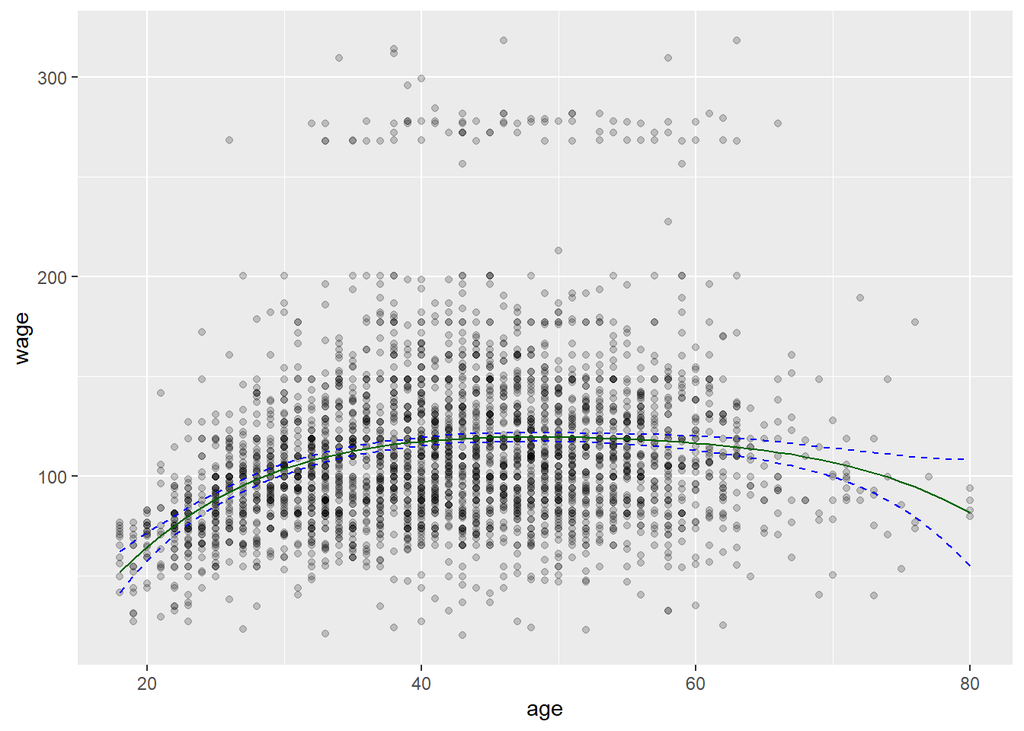

```r
Wage %>%
  ggplot(aes(age, wage)) +
  geom_point(alpha = 0.2) +
  geom_line(aes(y = .pred), color = "darkgreen",
            data = regression_lines) +
  geom_line(aes(y = .pred_lower), data = regression_lines,
            linetype = "dashed", color = "blue") +
  geom_line(aes(y = .pred_upper), data = regression_lines,
            linetype = "dashed", color = "blue")
```

Also note that if we expand the domain it was trained on the curves start diverging.

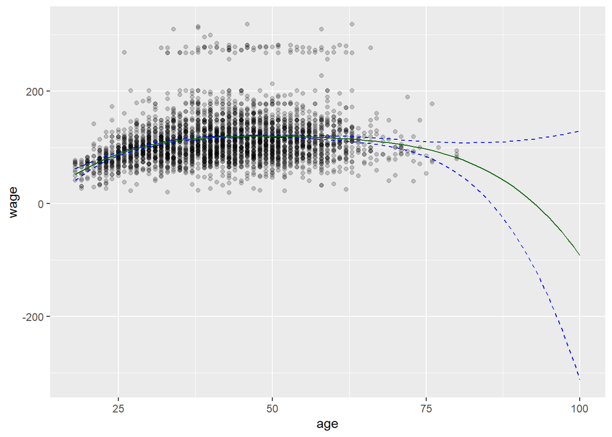

```r
wide_age_range <- tibble(age = seq(18, 100))

regression_lines <- bind_cols(
  augment(poly_fit, new_data = wide_age_range),
  predict(poly_fit, new_data = wide_age_range, type = "conf_int")
)

Wage %>%
  ggplot(aes(age, wage)) +
  geom_point(alpha = 0.2) +
  geom_line(aes(y = .pred), color = "darkgreen",
            data = regression_lines) +
  geom_line(aes(y = .pred_lower), data = regression_lines,
            linetype = "dashed", color = "blue") +
  geom_line(aes(y = .pred_upper), data = regression_lines,
            linetype = "dashed", color = "blue")
```

# THINKING OF POLYNOMIAL REGRESSION AS A CLASSIFICATION PROBLEM

GOAL: find whether an individual earns more than $250000 per year

Add a new factor denoting this response:

```r
Wage <- Wage %>%
  mutate(high = factor(wage > 250,
                       levels = c(TRUE, FALSE),
                       labels = c("High", "Low")))
```

Have to create a new polynomial expansion recipe because we have a new response variable:

```r
rec_poly <- recipe(high ~ age, data = Wage) %>%
  step_poly(age, degree = 4)

lr_spec <- logistic_reg() %>%
  set_engine("glm") %>%
  set_mode("classification")

lr_poly_wf <- workflow() %>%
  add_model(lr_spec) %>%
  add_recipe(rec_poly)
lr_poly_fit <- fit(lr_poly_wf, data = Wage)

predict(lr_poly_fit, new_data = Wage)
```

| .pred_class |
| --- |
| Low |
| Low |
| Low |
| Low |
| Low |
| Low |
| Low |
| Low |
| Low |
| Low |

[output cut: 2990 more lines]

If we want we can get the underlying probability predictions for the 2 classes, and their confidence intervals, by setting type = prob, and type = conf_int

```r
predict(lr_poly_fit, new_data = Wage, type = "prob")
```

| .pred_High | .pred_Low |
| --- | --- |
| 9.826427e-09 | 1.0000000 |
| 1.200780e-04 | 0.9998799 |
| 3.066352e-02 | 0.9693365 |
| 3.203914e-02 | 0.9679609 |
| 3.046630e-02 | 0.9695337 |
| 3.522567e-02 | 0.9647743 |
| 3.130812e-02 | 0.9686919 |
| 8.204864e-03 | 0.9917951 |
| 3.340341e-02 | 0.9665966 |
| 3.227216e-02 | 0.9677278 |

[output cut: 2990 more lines]

```r
predict(lr_poly_fit, new_data = Wage, type = "conf_int")
```

| .pred_lower_High | .pred_upper_High | .pred_lower_Low | .pred_upper_Low |
| --- | --- | --- | --- |
| 2.220446e-16 | 0.001660968 | 0.9983390 | 1.0000000 |
| 1.821549e-06 | 0.007855328 | 0.9921447 | 0.9999982 |
| 2.188989e-02 | 0.042799802 | 0.9572002 | 0.9781101 |
| 2.312871e-02 | 0.044226935 | 0.9557731 | 0.9768713 |
| 2.129656e-02 | 0.043409160 | 0.9565908 | 0.9787034 |
| 2.452922e-02 | 0.050345783 | 0.9496542 | 0.9754708 |
| 2.251163e-02 | 0.043389301 | 0.9566107 | 0.9774884 |
| 3.011469e-03 | 0.022155439 | 0.9778446 | 0.9969885 |
| 2.389120e-02 | 0.046522362 | 0.9534776 | 0.9761088 |
| 2.263220e-02 | 0.045825649 | 0.9541744 | 0.9773678 |

[output cut: 2990 more lines]

Let use these to visalize the probability curve for the classification model:

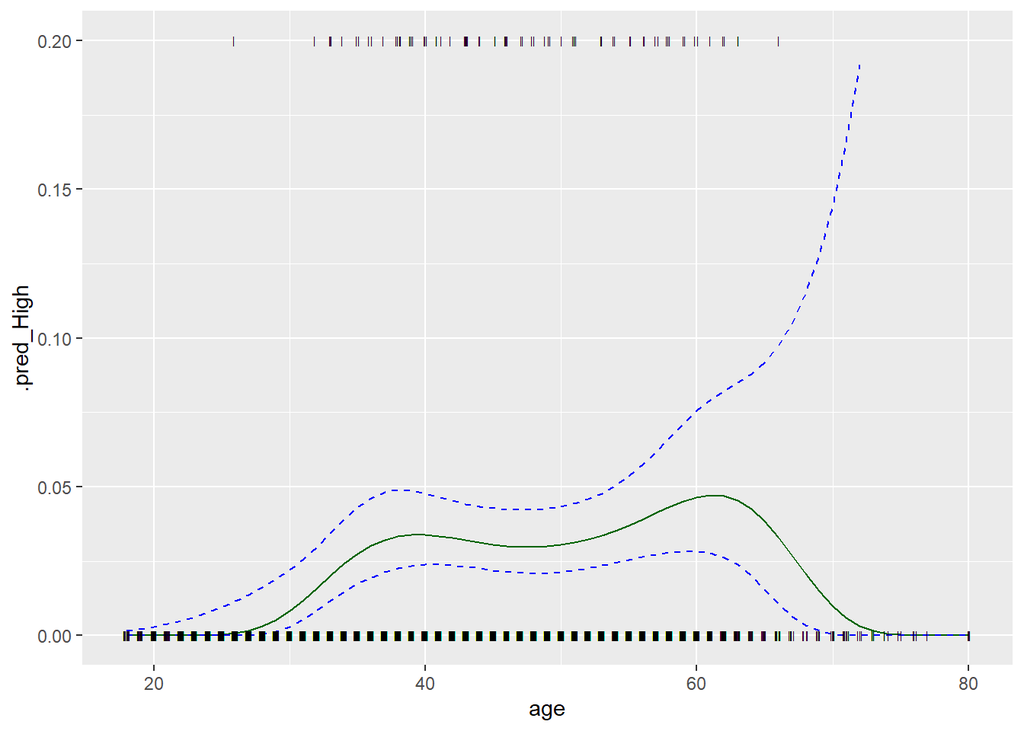

```r
regression_lines <- bind_cols(
  augment(lr_poly_fit, new_data = age_range, type = "prob"),
  predict(lr_poly_fit, new_data = age_range, type = "conf_int")
)

regression_lines %>%
  ggplot(aes(age)) +
  ylim(c(0, 0.2)) +
  geom_line(aes(y = .pred_High), color = "darkgreen") +
  geom_line(aes(y = .pred_lower_High), color = "blue", linetype = "dashed") +
  geom_line(aes(y = .pred_upper_High), color = "blue", linetype = "dashed") +
  geom_jitter(aes(y = (high == "High") / 5), data = Wage,
              shape = "|", height = 0, width = 0.2)
```

# FITTING A MODEL WITH THE STEP FUNCTION

step_discretize() - converts a numeric variable into a factor variable with n ubins - n = num_breaks - these breaks will have about the same number of points in them according to the training set data

```r
rec_discretize <- recipe(high ~ age, data = Wage) %>%
  step_discretize(age, num_breaks = 4)

discretize_wf <- workflow() %>%
  add_model(lr_spec) %>%
  add_recipe(rec_discretize)

discretize_fit <- fit(discretize_wf, data = Wage)
discretize_fit
```

```
## == Workflow [trained] ==========================================================
## Preprocessor: Recipe
## Model: logistic_reg()
##
## -- Preprocessor ----------------------------------------------------------------
## 1 Recipe Step
##
## * step_discretize()
##
## -- Model -----------------------------------------------------------------------
##
## Call:  stats::glm(formula = ..y ~ ., family = stats::binomial, data = data)
##
## Coefficients:
## (Intercept)      agebin2      agebin3      agebin4
##       5.004       -1.492       -1.665       -1.705
##
## Degrees of Freedom: 2999 Total (i.e. Null);  2996 Residual
## Null Deviance:       730.5
## Residual Deviance: 710.4     AIC: 718.4
```

Can also fo mannualy via step_cut() if you already know where the step functions breaks

```r
rec_cut <- recipe(high ~ age, data = Wage) %>%
  step_cut(age, breaks = c(30, 50, 70))

cut_wf <- workflow() %>%
  add_model(lr_spec) %>%
  add_recipe(rec_cut)

cut_fit <- fit(cut_wf, data = Wage)
cut_fit
```

```
## == Workflow [trained] ==========================================================
## Preprocessor: Recipe
## Model: logistic_reg()
##
## -- Preprocessor ----------------------------------------------------------------
## 1 Recipe Step
##
## * step_cut()
##
## -- Model -----------------------------------------------------------------------
##
## Call:  stats::glm(formula = ..y ~ ., family = stats::binomial, data = data)
##
## Coefficients:
## (Intercept)   age(30,50]   age(50,70]   age(70,80]
##       6.256       -2.746       -3.038       10.310
##
## Degrees of Freedom: 2999 Total (i.e. Null);  2996 Residual
## Null Deviance:       730.5
## Residual Deviance: 704.3     AIC: 712.3
```

# SPLINES

- in order to fit regression splines use step_bs()

```r
rec_spline <- recipe(wage ~ age, data = Wage) %>%
  step_bs(age, options = list(knots = 25, 40, 60))
```

Create a workflow and predict:

```r
spline_wf <- workflow() %>%
  add_model(lm_spec) %>%
  add_recipe(rec_spline)

spline_fit <- fit(spline_wf, data = Wage)

predict(spline_fit, new_data = Wage)
```

| .pred |
| --- |
| 58.68868 |
| 84.27424 |
| 120.45415 |
| 119.77826 |
| 120.36572 |
| 118.80241 |
| 120.17210 |
| 102.16531 |
| 118.63478 |
| 119.72612 |

[output cut: 2990 more lines]

Lets look at the basic spline on top of the data:

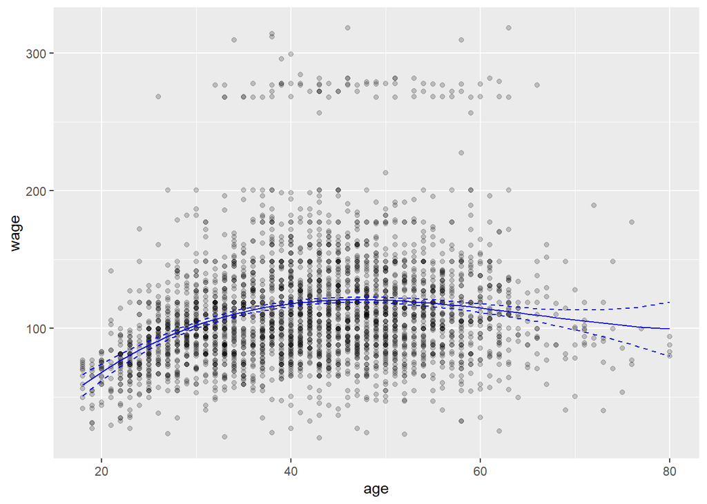

```r
regression_lines <- bind_cols(
  augment(spline_fit, new_data = age_range),
  predict(spline_fit, new_data = age_range, type = "conf_int")
)

Wage %>%
  ggplot(aes(age, wage)) +
  geom_point(alpha = 0.2) +
  geom_line(aes(y = .pred), data = regression_lines, color = "blue") +
  geom_line(aes(y = .pred_lower), data = regression_lines,
            linetype = "dashed", color = "blue") +
  geom_line(aes(y = .pred_upper), data = regression_lines,
            linetype = "dashed", color = "blue")
```

NOTE: splines take the breaks from above and makes them continuous with each other.